# CSE204 - Introduction to Machine Learning - Lab Session 4: regression methods

#### Question 2

What happens when you change the value of the variable `sigma` parameter (try e.g. `sigma=0.3`)? Why?

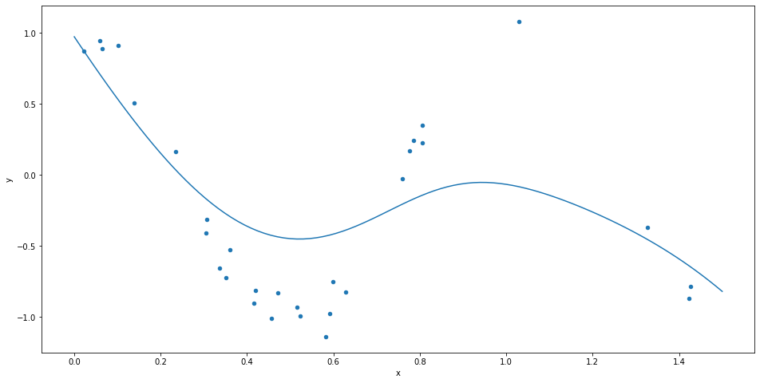

```python
x_pred = np.linspace(0., 1.5, 100)
# y_pred = ...

### BEGIN SOLUTION
y_pred = [locally_weighted_regression(x, dataset, sigma=0.3) for x in x_pred]
### END SOLUTION

ax = dataset.plot.scatter(x='x', y='y', figsize=(16, 8))
ax.plot(x_pred, y_pred);
```

$\sigma$ controls the width of the kernel, so that the regression becomes less "local" (points far from the prediction point start having at least some importance as well). With $\sigma = \infty$, we're back to linear regression.

#### Question 3

Can we use Local Linear Regression to forecast time series as it was asked in the exercise 7 of the lab session 2? (You can try it out in the cells below.) Why?

```python
URL = "https://raw.githubusercontent.com/adimajo/CSE204-2021/master/data/natural_gas_co2_emissions_for_electric_power_sector.csv"
df = pd.read_csv(URL, parse_dates=[0])

df['x'] = df.index
df['y'] = df.co2_emissions

df[['x','y']].head()
```

|  | x | y |
| --- | --- | --- |
| 0 | 0 | 12.175 |
| 1 | 1 | 11.708 |
| 2 | 2 | 13.994 |
| 3 | 3 | 14.627 |
| 4 | 4 | 17.344 |

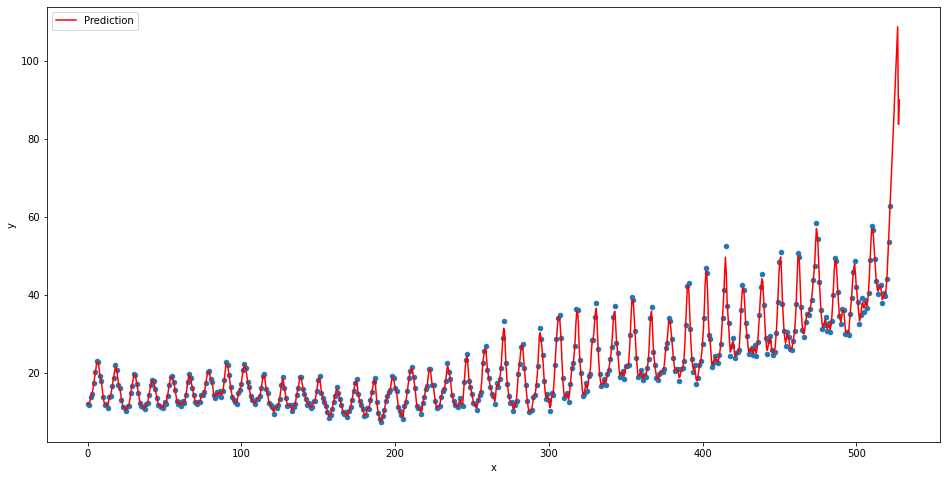

```python
x_pred = np.linspace(0., len(df) + 5, 1000)
# y_pred = ...

### BEGIN SOLUTION
y_pred = [locally_weighted_regression(x, df, sigma=0.5) for x in x_pred]
### END SOLUTION

ax = df.plot.scatter(x='x', y='y', figsize=(16, 8))
ax.plot(x_pred, y_pred, "-r", label="Prediction")
plt.legend();
```

This method shows poor performance when the new point to predict is located outside the area (what is usually called the "support") of known examples.